S2 Statistika Terapan FMIPA Unpad

Berita Kegiatan Mahasiswa

# Workshop Pemodelan Asuransi Gempa dan Retensi Optimal

Salah satu mahasiswa S2 Statistika Terapan FMIPA Universitas Padjadjaran memperluas kompetensi aktuaria, pemodelan risiko katastrofe, dan komputasi statistik melalui workshop internasional di Bandung.

📅 7 Agustus 2026 📍 éL Hotel Bandung ⏱️ 08.00–17.00 WIB

[figure not shown]

International Actuarial Research Conference 2026

## Mahasiswa S2 Statistika Terapan FMIPA Unpad Mengikuti Workshop “Earthquake Insurance/Reinsurance Modeling: An Optimal Retention”

**Bandung, 7 Agustus 2026** — Salah satu mahasiswa Program Studi S2 Statistika Terapan FMIPA Universitas Padjadjaran mengikuti workshop bertajuk *“Earthquake Insurance/Reinsurance Modeling: An Optimal Retention”* yang diselenggarakan sebagai bagian dari *The 2026 International Actuarial Research Conference*.

Kegiatan dilaksanakan secara tatap muka di éL Hotel Bandung pada Jumat, 7 Agustus 2026, pukul 08.00–17.00 WIB. Workshop mempertemukan akademisi, praktisi aktuaria, dan peserta dari berbagai institusi untuk mempelajari pemodelan risiko gempa bumi dalam konteks asuransi dan reasuransi.

Materi workshop membahas alur pemodelan risiko bencana secara terintegrasi, mulai dari data bahaya gempa, eksposur aset, kerentanan, estimasi kerugian finansial, hingga penentuan retensi reasuransi yang optimal. Peserta juga diperkenalkan pada penggunaan Python untuk pengolahan data, visualisasi, dan simulasi risiko.

Alur utama pembelajaran: **earthquake hazard → exposure → vulnerability → financial loss → reinsurance optimization.**

Salah satu pokok pembahasan utama adalah penyusunan *Event Loss Table* (ELT) secara probabilistik. Distribusi magnitudo gempa utama dimodelkan menggunakan *Generalized Pareto Distribution*, lalu dikombinasikan dengan model kerugian untuk menghasilkan berbagai kemungkinan skenario kerugian finansial.

Workshop juga membahas penerapan *collective risk model* dan simulasi Monte Carlo untuk mengevaluasi distribusi kerugian akibat kejadian gempa. Hasil simulasi selanjutnya digunakan untuk menghitung *Average Annual Loss* (AAL), mengukur tingkat risiko portofolio, dan menentukan besarnya retensi yang sesuai bagi perusahaan asuransi maupun reasuransi.

Dalam kegiatan tersebut, mahasiswa S2 Statistika Terapan FMIPA Unpad mengikuti praktik pengolahan dan visualisasi data gempa bumi, eksplorasi katalog gempa, pemetaan kejadian berdasarkan magnitudo dan kedalaman, serta simulasi model *hazard–exposure–vulnerability–financial loss*. Peserta mempelajari bagaimana data gempa BMKG dapat dikembangkan menjadi informasi kuantitatif yang mendukung pengambilan keputusan di bidang aktuaria dan manajemen risiko.

Partisipasi mahasiswa dalam workshop ini memperlihatkan keterkaitan yang kuat antara statistika terapan, ilmu aktuaria, analisis spasial, pemodelan probabilistik, dan manajemen risiko bencana. Kegiatan ini sekaligus memberikan pengalaman praktis dalam mengembangkan model berbasis data nyata dan menerjemahkan hasil analisis statistik menjadi rekomendasi bisnis.

Melalui kegiatan akademik seperti ini, Program Studi S2 Statistika Terapan FMIPA Unpad terus mendorong mahasiswa untuk memperluas pengalaman pembelajaran di luar kelas, berinteraksi dengan praktisi, serta menghasilkan aplikasi statistika yang relevan dengan persoalan nyata di masyarakat dan industri.

### Informasi Kegiatan

🗓️

**Tanggal**7 Agustus 2026

🕗

**Waktu**08.00–17.00 WIB

📍

**Tempat**éL Hotel Bandung

💻

**Perangkat Komputasi**Python, R Shiny, dan Streamlit

### Topik Utama

🌏

**Earthquake Catastrophe Model**Hazard, exposure, vulnerability, dan financial loss

📊

**Magnitude Distribution**GPD dan simulasi magnitudo

🎲

**Monte Carlo**Simulasi skenario kerugian

🛡️

**Optimal Retention**Strategi retensi asuransi dan reasuransi

## Teks dari Brosur Workshop

Transkripsi pokok informasi yang tercantum pada brosur kegiatan.

[figure not shown]

### Workshop @ The 2026 International Actuarial Research Conference

**Earthquake Insurance/Reinsurance Modeling: An Optimal Retention**

**Date:** 7 August 2026  
**Time:** 08:00–17:00  
**Mode:** Full on-site  
**Venue:** éL Hotel Bandung

### Course Material Overview

*The workshop will use Python and discuss the following:*

1. Introduction to Basic Python.
2. The construction of an Event Loss Table (ELT) probabilistically for tectonic earthquakes, utilizing the probability distribution of the moment magnitudes of earthquake mainshocks modeled by a Generalized Pareto Distribution (GPD).
3. The application of Collective Risk models and Monte Carlo simulations to generate multi-scenario financial-loss risks based on selected Average Recurrence Intervals (Return Periods) of tectonic earthquakes.
4. The utilization of the Average Annual Loss (AAL) produced by the ELT, using certain assumptions to obtain an optimal retention for an earthquake insurance or reinsurance business.

**Professional development:** 3 CPD Points are provided for eligible non-presenter members of the Society of Actuaries of Indonesia who participate in the full conference and workshop program, subject to the organizer’s provisions.

## Galeri Kegiatan

Klik foto untuk memperbesar.

[figure not shown]

Eksplorasi sumber data dan materi pemodelan gempa selama workshop.

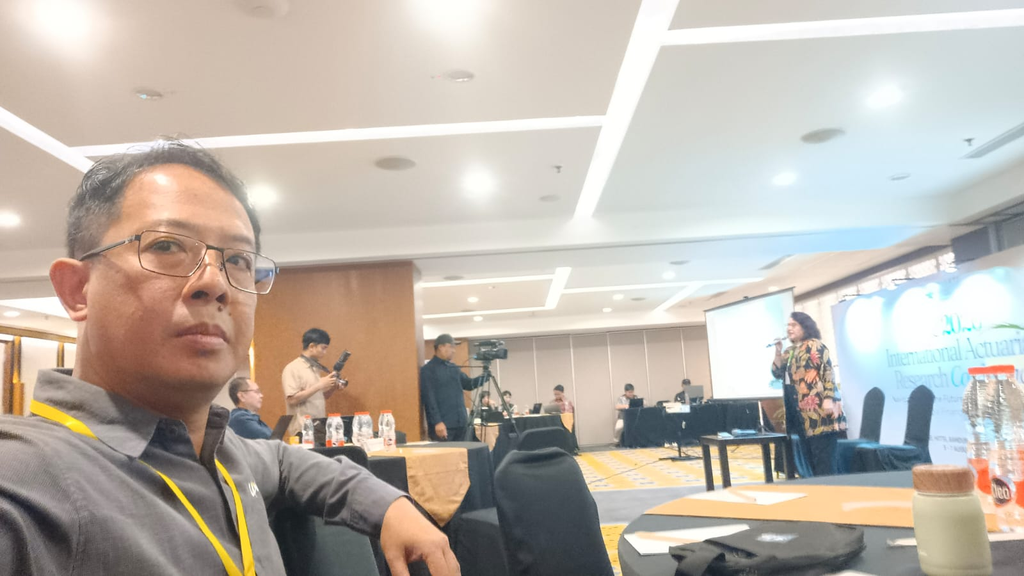

Mahasiswa S2 Statistika Terapan FMIPA Unpad mengikuti sesi pemaparan.

[figure not shown]

Visualisasi katalog gempa Indonesia berdasarkan magnitudo.

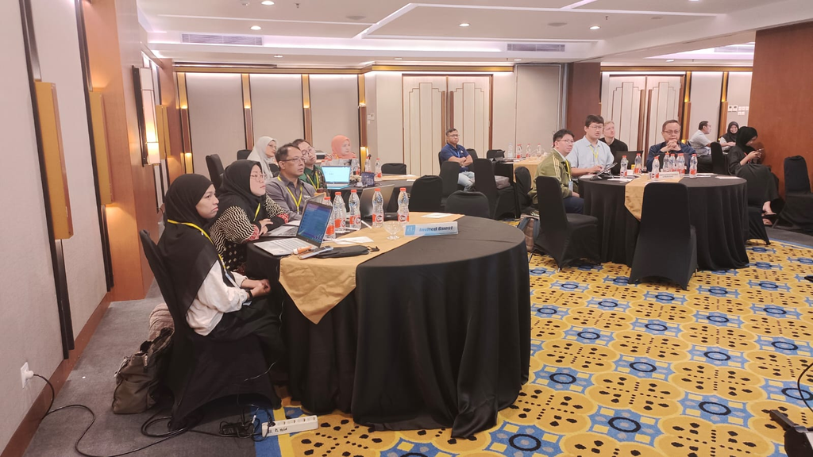

Suasana peserta dalam sesi workshop internasional di Bandung.

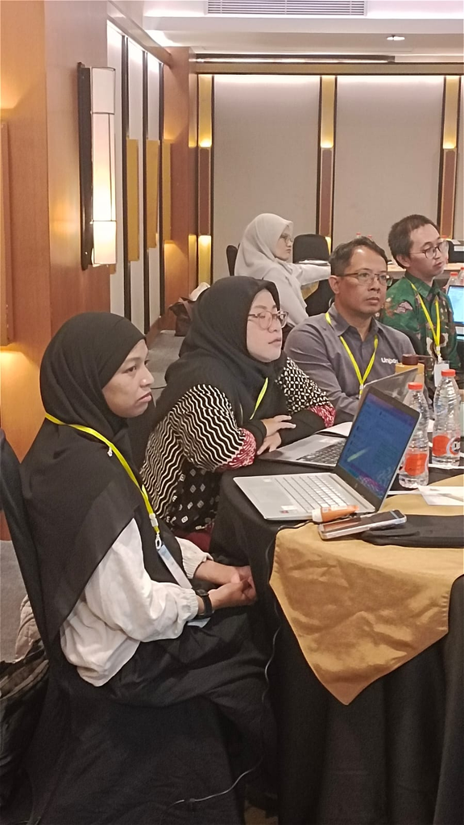

Diskusi dan pengamatan materi pada sesi pemodelan risiko.

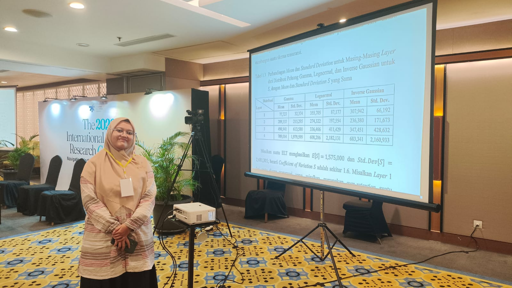

Pembahasan distribusi kerugian dan skema reasuransi.

## Output Pembelajaran dan Aplikasi

Dua aplikasi interaktif untuk pengolahan data, catastrophe modeling, AAL, dan optimal retention.

[figure not shown]

### Earthquake Insurance Lab — R Shiny

Memuat materi workshop, data BMKG, QC dan EDA, model distribusi magnitudo, catastrophe model, annual loss, optimal retention, serta laboratorium R dan Python.

[Buka aplikasi R Shiny ↗](https://diseasemodel.shinyapps.io/earthquake_workshop_app_v2/)

[figure not shown]

### Earthquake Insurance/Reinsurance — Streamlit

Menyediakan simulasi model hazard–exposure–vulnerability–financial loss, pengaturan portofolio, parameter polis, site amplification, insured loss, dan evaluasi skenario risiko.

[Buka aplikasi Streamlit ↗](https://earthquake-insurance-app-skem4wesjqfvaesgkhr7ha.streamlit.app/catastrophe_model)

**Keterangan foto:** Mahasiswa S2 Statistika Terapan FMIPA Unpad mengikuti pemaparan materi dan praktik pemodelan asuransi gempa dalam workshop *Earthquake Insurance/Reinsurance Modeling: An Optimal Retention* di éL Hotel Bandung, 7 Agustus 2026.

[figure not shown]